# Red de Señalización

Mayela Fosado

23/3/2022

## **Red de Señalización**

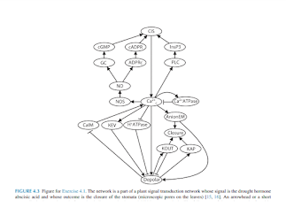

Figura 1

Con la figura 1, responder:

## **a) Elabora una representación verbal de la red.**

1. El ion de Ca induce la expresión de NOS, activa a PLC, al AnionME, KEV y al CaATPase.
2. A su vez CaATPase, lo inhibe y limita a Ca, el Ca también necesita de CIS para que favorezca su inducción.
3. Para que esté CIS activo necesita de cADPR, cGMP e InsP3, pero para que todo esto se dé, tienen que estar otros activos, los cuales comienzan a inducirse por Ca.
4. Ca activa a NOS y NOS a su vez activa a No, que activa a GC y APRc, GC activa a cGMP y activa a CIS. En cambio, ADPRc activa a cADPR que también es necesario para activar a CIS.
5. InsP3, que también activa a CIS, es activado por PLC, que a su vez es activado por Ca y activa a CIS.
6. Además de que Ca activa a CaATPase y a NOS, activa a KEV y al AnionEM, e inhibe a H+ATPase, los primeros dos activan a Depolar, el cual inhibe a CalM que también activa a Ca, por lo que cuando Depolar contribuye para inhibir a Ca, por medio de CalM.
7. AnionEM activa a Closure, el cual es activado también por KOUT y KAP, ambos son activados por Depolar, pero este es inhibido por KOUT.
8. Cuando no está Ca y está activo H+ATPase inhibe a Depolar, al igual que KOUT.

## **b) Elabora las posibles reglas de la red.**

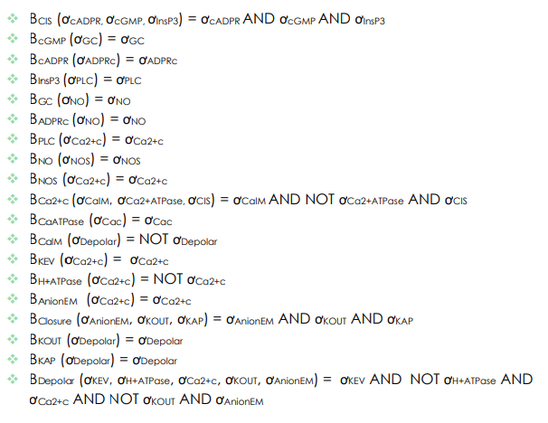

## **c) Encontrar los atractores y discutir biológicamente.**

```r
library(BoolNet)
red <- loadNetwork("Red_senn.txt")
red
```

```
## Boolean network with 19 genes
##
## Involved genes:
## CIS cGMP cADPR InsP3 GC ADPRc PLC NO NOS Cac CaATPase CalM KEV HATPase AnionEM Closure KOUT KAP Depolar
##
## Transition functions:
## CIS = cADPR & cGMP & InsP3
## cGMP = GC
## cADPR = ADPRc
## InsP3 = PLC
## GC = NO
## ADPRc = NO
## PLC = Cac
## NO = NOS
## NOS = Cac
## Cac = CalM & !CaATPase & CIS
## CaATPase = Cac
## CalM = !Depolar
## KEV = Cac
## HATPase = !Cac
## AnionEM = Cac
## Closure = AnionEM & KOUT & KAP
## KOUT = Depolar
## KAP = Depolar
## Depolar = KEV & !HATPase & Cac & !KOUT & AnionEM
```

```r
atractores <- getAttractors(red)
atractores
```

```
## Attractor 1 is a simple attractor consisting of 1 state(s) and has a basin of 524288 state(s):
##
##  |--<------------------|
##  V                     |
##  0000000000010100000   |
##  V                     |
##  |-->------------------|
##
##
## Genes are encoded in the following order: CIS cGMP cADPR InsP3 GC ADPRc PLC NO NOS Cac CaATPase CalM KEV HATPase AnionEM Closure KOUT KAP Depolar
```

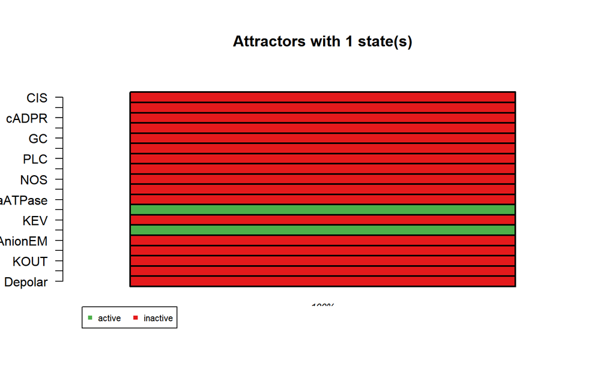

```
## $`1`
##          Attr1.1
## CIS            0
## cGMP           0
## cADPR          0
## InsP3          0
## GC             0
## ADPRc          0
## PLC            0
## NO             0
## NOS            0
## Cac            0
## CaATPase       0
## CalM           1
## KEV            0
## HATPase        1
## AnionEM        0
## Closure        0
## KOUT           0
## KAP            0
## Depolar        0
```

```r
plotAttractors(atractores)
```

En total se obtuvo un 1 atractor y 524288 estados, lo cual me sorprendió bastante, donde solo quedan CalM y H+ATPase activos.

Para el total de estados, 1 atractor es muuuuy poco, por lo que, es probable que ya que, en las reglas solo utilicé AND y no OR, eso haya afectado el número de atractores. Probablemente se hubieran obtenido más, ya que no era necesario que por ejemplo en Closure hubiera 3 activándolo.

Entonces, su signficado de esto es, que los atractores representan los genotipos que pueden existir, y en este caso solo se obtuvo uno y pues solo hay una cuenca de atracción hacia ese.